# cox_subgroup_forest() Tutorial

Julian Silan

2026-08-19

Source the function first (adjust the path to wherever `forestplot_subgroup_function.R` lives relative to this `.Rmd` file):

```r
source("/Users/julian/Desktop/VHIO/R code/Forestplot/Subgroup/forestplot_subgroup_function.R")
```

```r
library(survival)
library(dplyr)
```

# 1 Prepare the data

```r
set.seed(42)

lung2 <- survival::lung %>%
  mutate(
    event_os  = status - 1,                       # 1 = death, 0 = censored
    time_os   = time,
    sex       = factor(sex, levels = c(1, 2), labels = c("Male", "Female")),
    ph.ecog   = factor(ph.ecog),                   # 0-3 performance status
    treatment = sample(c("Arm A", "Arm B"), n(), replace = TRUE),
    time_pfs  = pmin(time_os, time_os * runif(n(), 0.4, 0.9)),
    event_pfs = ifelse(time_pfs < time_os, 1, event_os)
  ) %>%
  filter(!is.na(ph.ecog), !is.na(sex), !is.na(age))

#glimpse(lung2)
```

> `time_pfs` / `event_pfs` here are a *simulated* PFS endpoint (PFS event always occurs no later than OS) purely so the tutorial has two endpoints to work with — `survival::lung` does not contain real PFS data.

# 2 The simplest use

The simplest possible call: one categorical covariate, one endpoint, univariable model.

```r
res_sex <- cox_subgroup_forest(
  data = lung2,
  covariates = c("sex"),
  labels = c("Sex"),
  treatment = "treatment",
  time = c("time_os"),
  event = c("event_os"),
  endpoint_labels = c("Overall Survival"),
  time_unit = "days",
  palette = c("#0F084B")
)

res_sex$results_table
```

| covariate | covariate_label | subgroup | indent | endpoint | endpoint_label | n | n_event | median_a | median_b | hr | conf_low | conf_high | p_value |
| --- | --- | --- | --- | --- | --- | --- | --- | --- | --- | --- | --- | --- | --- |
| sex | Sex | All patients | FALSE | time_os | Overall Survival | 227 | 164 | 320 | 310 | 0.9685883 | 0.7115999 | 1.318386 | 0.8392269 |
| sex | Sex | Male | TRUE | time_os | Overall Survival | 137 | 111 | 288 | 267 | 1.0157825 | 0.6990297 | 1.476066 | 0.9345480 |
| sex | Sex | Female | TRUE | time_os | Overall Survival | 90 | 53 | 444 | 426 | 0.7662301 | 0.4370521 | 1.343338 | 0.3525971 |

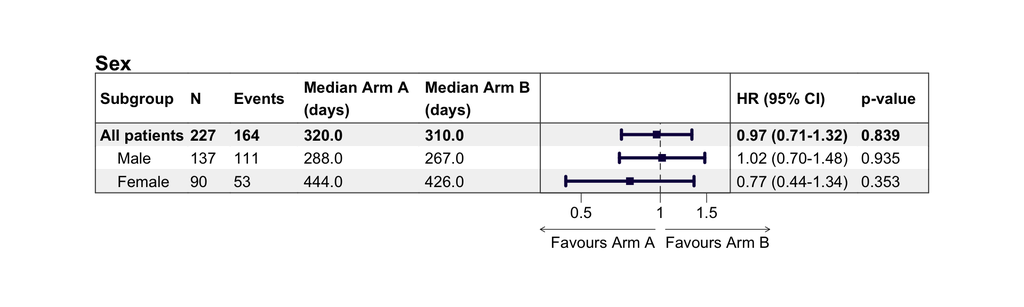

```r
res_sex$plots$Sex
```